# Assignment!

# Assignment 1

## Tidying Data

```r
library(ggplot2)
library(tidyverse)
library(readxl)
passengers<-read_xls("WebAirport_FY_1986-2017.xls", sheet=3, skip=6)
passengers1 <- passengers[-c(1,4,7,10,11,12,13,14)]
passengers2 <- filter(passengers1, AIRPORT != "TOTAL AUSTRALIA")
passengers3 <- gather(passengers2, key = "Bound", value = "Count", -AIRPORT, -Year)
passengers3 <- mutate(passengers3, TypeOfFlight = Bound)
passengers4 <- passengers3 %>% mutate(Bound = stringr::str_replace(Bound, "OUTBOUND__1", "OUTBOUND"))
passengers5 <- passengers4 %>% mutate(Bound = stringr::str_replace(Bound, "INBOUND__1", "INBOUND"))
passengers6 <- passengers5 %>% mutate(TypeOfFlight = stringr::str_replace(TypeOfFlight, "INBOUND__1", "International"))
passengers7 <- passengers6 %>% mutate(TypeOfFlight = stringr::str_replace(TypeOfFlight, "INBOUND", "Domestic"))
passengers8 <- passengers7 %>% mutate(TypeOfFlight = stringr::str_replace(TypeOfFlight, "OUTBOUND__1", "International"))
passengers9 <- passengers8 %>% mutate(TypeOfFlight = stringr::str_replace(TypeOfFlight, "OUTBOUND", "Domestic"))
passengers_tidy <- passengers9[c(1,2,3,5,4)]
passengers_tidy
```

```
## # A tibble: 12,544 x 5
##    AIRPORT  Year    Bound   TypeOfFlight    Count
##    <chr>    <chr>   <chr>   <chr>           <dbl>
##  1 ADELAIDE 1985-86 INBOUND Domestic      984010.
##  2 ADELAIDE 1986-87 INBOUND Domestic      973288.
##  3 ADELAIDE 1987-88 INBOUND Domestic     1047798.
##  4 ADELAIDE 1988-89 INBOUND Domestic     1075380.
##  5 ADELAIDE 1989-90 INBOUND Domestic      823571.
##  6 ADELAIDE 1990-91 INBOUND Domestic     1136965.
##  7 ADELAIDE 1991-92 INBOUND Domestic     1403103.
##  8 ADELAIDE 1992-93 INBOUND Domestic     1408479.
##  9 ADELAIDE 1993-94 INBOUND Domestic     1510831.
## 10 ADELAIDE 1994-95 INBOUND Domestic     1634705.
## # ... with 12,534 more rows
```

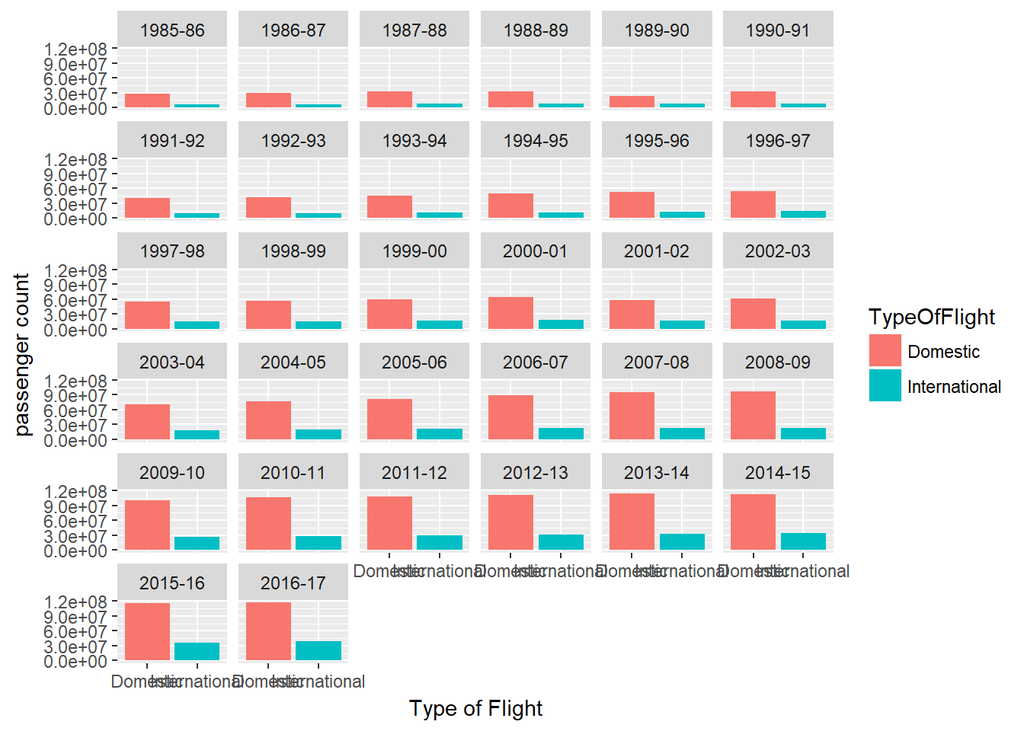

```r
## Bar graph of flight type, facetted by year
ggplot(passengers_tidy, aes(x=TypeOfFlight, fill=TypeOfFlight)) + geom_bar(aes(weight=Count)) + facet_wrap(~Year) + xlab("Type of Flight") + ylab("passenger count")
```

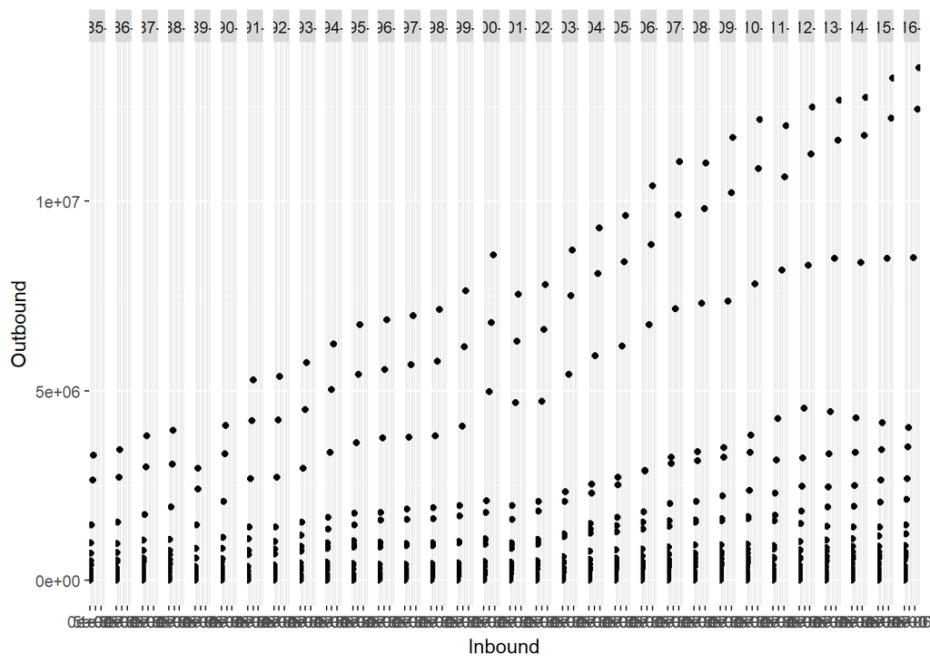

```r
##Scatterplot of domestic inbound vs outbound, facetted by year
passengers_domestic<-spread(passengers_tidy, key=TypeOfFlight, value= Count)
passengers_inout<-spread(passengers_tidy, key=Bound, value = Count)
passengers_inoutdom<-filter(passengers_inout, TypeOfFlight == "Domestic")
ggplot(passengers_inoutdom, aes(x=INBOUND, y=OUTBOUND)) +geom_point() + facet_grid(~Year) + xlab("Inbound") + ylab("Outbound")
```

```r
airpopular<-filter(passengers_inoutdom, Year=="2000-01")
arrange(airpopular, desc(OUTBOUND))
```

```
## # A tibble: 98 x 5
##    AIRPORT    Year    TypeOfFlight  INBOUND OUTBOUND
##    <chr>      <chr>   <chr>           <dbl>    <dbl>
##  1 SYDNEY     2000-01 Domestic     8686885. 8589241.
##  2 MELBOURNE  2000-01 Domestic     6823806. 6804774.
##  3 BRISBANE   2000-01 Domestic     4948279. 4979622.
##  4 ADELAIDE   2000-01 Domestic     2089536. 2089239.
##  5 PERTH      2000-01 Domestic     1769809. 1785121.
##  6 CAIRNS     2000-01 Domestic     1089488. 1100239.
##  7 CANBERRA   2000-01 Domestic     1051311. 1055908.
##  8 GOLD COAST 2000-01 Domestic      915099.  939110.
##  9 HOBART     2000-01 Domestic      487932.  485990.
## 10 DARWIN     2000-01 Domestic      448362.  457236.
## # ... with 88 more rows
```

```r
#Sydney, Melbourne then Brisbane are the busiest airports,
```

### The scatterplot shows that as the number of domestic inbound flights increase so does that the number of domestic outbound flights. There is also three airports that clearly have a greater number of flights which are Sydney, Melbourne and Brisbane (in order of number of flights), this is visible by arranging the airpopular dataframe by traffic, in descending order. Also there is a visible upward trend in inbound vs outbound passengers at a similar rate within the larger airports, compared to the smaller which have a more stagnant rate.

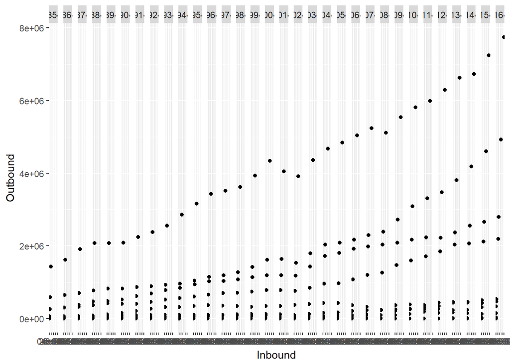

```r
##Scatterplot of international inbound vs outbound passengers, facetted by year
passengers_int<-filter(passengers_tidy, TypeOfFlight == "International")
passengers_inoutint<-spread(passengers_int, key=Bound, value = Count)
ggplot(passengers_inoutint, aes(x=INBOUND, y=OUTBOUND)) + geom_point() + facet_grid(~Year) + xlab("Inbound") + ylab("Outbound")
```

```r
airpopularint<-filter(passengers_inoutint, Year=="2000-01")
```

### A scatterplot of international inbound vs outbound passengers shows positive growth overtime. As with the domestic flights the three airports with the most traffic are Sydney followed by Melbourne and then Brisbane, but when international is shown it is visible that Perth as well receives a significant number of international flights. It is seen that Sydney conducts considerably more flights even compared to its closest competitor Melbourne. Ultimately as the number of inbound international flights increase so does outbound flights.